# Week 6 - Longitudinal Data

Kalle Kivinen

12/2/2020

## The MABS Chapter 8 Analysis with the RATS data.

### Introduction

The RATS dataset measures the body weight of three groups of rats at various points in time. The groups are differentiated by the diets they were fed and their weight is measured in grams. Below the reader can find a table of the RATS dataset in wide and long form. The difference between these two forms of data is covered in the data-wrangling exercise.

```
##     X ID Group WD1 WD8 WD15 WD22 WD29 WD36 WD43 WD44 WD50 WD57 WD64
## 1   1  1     1 240 250  255  260  262  258  266  266  265  272  278
## 2   2  2     1 225 230  230  232  240  240  243  244  238  247  245
## 3   3  3     1 245 250  250  255  262  265  267  267  264  268  269
## 4   4  4     1 260 255  255  265  265  268  270  272  274  273  275
## 5   5  5     1 255 260  255  270  270  273  274  273  276  278  280
## 6   6  6     1 260 265  270  275  275  277  278  278  284  279  281
## 7   7  7     1 275 275  260  270  273  274  276  271  282  281  284
## 8   8  8     1 245 255  260  268  270  265  265  267  273  274  278
## 9   9  9     2 410 415  425  428  438  443  442  446  456  468  478
## 10 10 10     2 405 420  430  440  448  460  458  464  475  484  496
## 11 11 11     2 445 445  450  452  455  455  451  450  462  466  472
## 12 12 12     2 555 560  565  580  590  597  595  595  612  618  628
## 13 13 13     3 470 465  475  485  487  493  493  504  507  518  525
## 14 14 14     3 535 525  530  533  535  540  525  530  543  544  559
## 15 15 15     3 520 525  530  540  543  546  538  544  553  555  548
## 16 16 16     3 510 510  520  515  530  538  535  542  550  553  569
```

```
##     X ID Group  WD Weight Time
## 1   1  1     1 WD1    240    1
## 2   2  2     1 WD1    225    1
## 3   3  3     1 WD1    245    1
## 4   4  4     1 WD1    260    1
## 5   5  5     1 WD1    255    1
## 6   6  6     1 WD1    260    1
## 7   7  7     1 WD1    275    1
## 8   8  8     1 WD1    245    1
## 9   9  9     2 WD1    410    1
## 10 10 10     2 WD1    405    1
## 11 11 11     2 WD1    445    1
## 12 12 12     2 WD1    555    1
## 13 13 13     3 WD1    470    1
## 14 14 14     3 WD1    535    1
```

[output cut: 16 more lines]

### The Analysis

To initiate the exploration of the data, we can run it through some graphical tools. As MABS chapter 8 notes, these graphical approaches, together with the summary measure approach, provide a *quick and dirty* way of analysing the data. To start the analysis, we will begin by handling the dataset graphically to extract information.

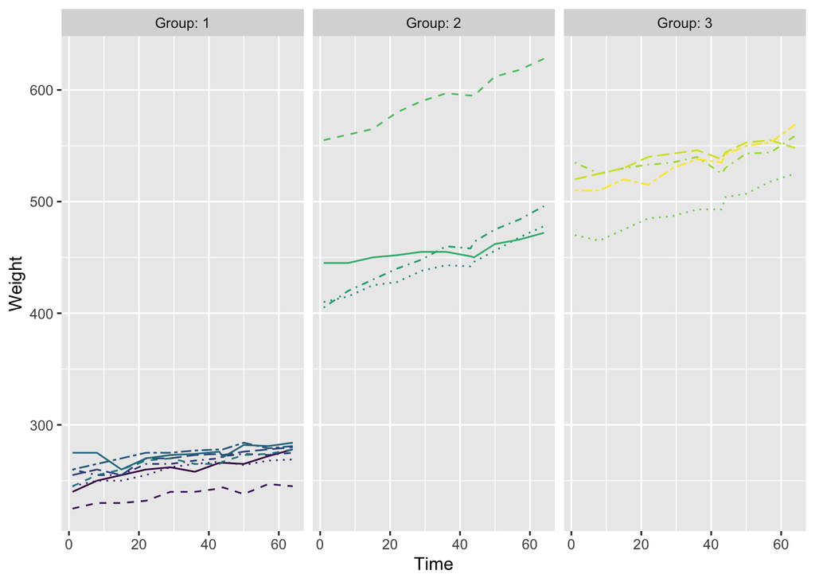

The groups showcase the “Tracking”-effect, whereby larger starting values predict larger ending values. This effect applies as a probabilistic predictor. Ie. a larger starting value does not *determine* a larger ending value, it merely *makes it more probable*. As such, larger starting values do not always translate to larger ending values. But, most often they do.

To really bring out the effects of “tracking,” we need to standardize the data. Understanding the effects of “tracking” is important, because otherwise we are unable to truly delimit the effects of the diet from the effects of the starting size.

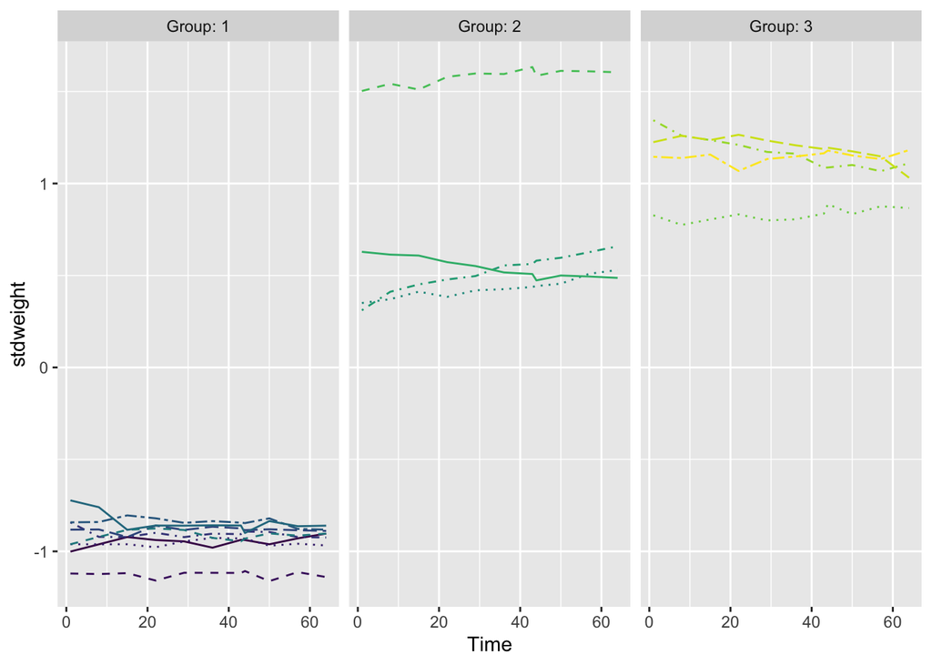

The above graphs showcase the effects of both tracking and time on the datasets. In a standardized format, we are able to see that the varying diets have little effect on the weights of the mice. This means that starting size and growth-caused-by-aging explain much of the change. In fact, only group two (if we ignore the full straight line) shows compelling signs of growth brought on by the diet alone. Groups one and three seem to follow the standard pattern.

Moving on to the summary graph, we summarize the data through the means of each group.

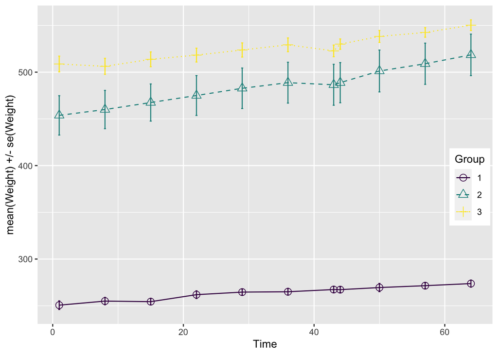

As we are interested in the general, or *mean* effect of the diets on the mice, the above plot provides us with plenty of information. It shows us that group 2 has the fastest growth in weight out of the three groups. Group 3 has the second fastest growth, while group 1 remain almost stagnant.

This is not, though, the end of the analysis. We need to figure out whether certain observations are outliers and consequently contribute excessively to the results. The box plot graph is a good approach to determine this.

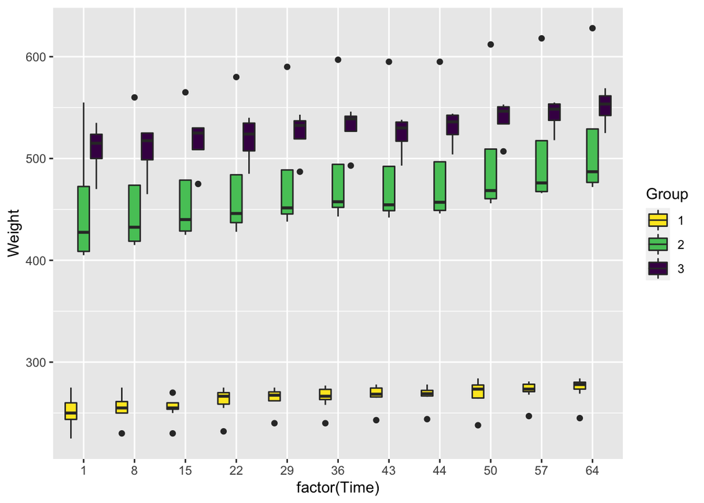

As is clear from the data, we are able to observe an outlier in each group. In both groups one and three, the outlier pulls the averages down, whereas with group two it increases it. There are certain situation where this might be problematic - such as when measuring the weights of mice at specific points in time - but if we are interested in the growth rates (as is the case here), these outliers do not seem to have a significant effect. This is because their variance is stable throughout the time frame. As such the outliers do not contribute to the difference in change of outcome between groups.

In the book the summary measure that is applied to the data is the measurement of differences in the *means* of the groups. This is a good approach for the BPRS data, because it is supposed to track the effectiveness of a treatment. As the RATS-data measures the effect of a diet on the growth of mice, we would be better served by the use of the regression coefficient as the summary measure - as per the MABS chapter 8, page 162. Nevertheless, this comes so close to the work done in chapter 9 that despite the poorer fit of the *mean*-summary measure, we will apply it here to the RATS data. As such, we will treat the diet as a once-off measure. Conceptually, this approach could be justified - for example - when measuring the effects of the diet of adolescent rats on their development to mature, fully grown rats. In such a case, the effects are cemented in - as if we were talking about the effects of a treatment. Nevertheless, there is no reason to ignore the baseline in this case and as such that part will not be carried out.

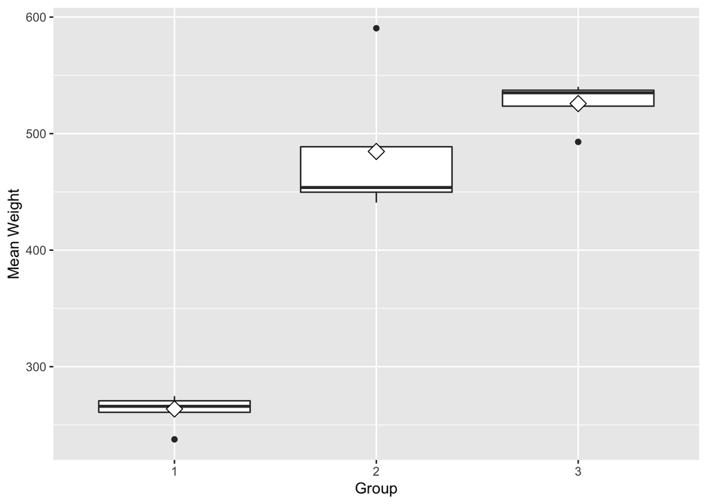

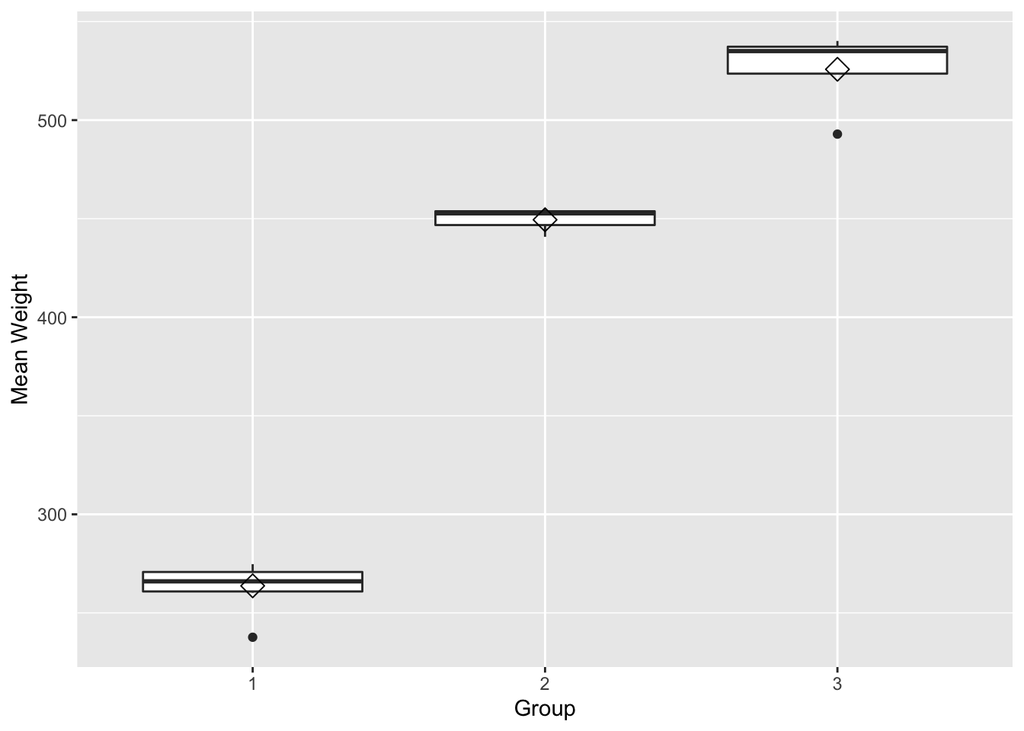

What the above graph shows is that variance in the results of groups 1 and 3 are negligeble, while group 2’s variance is somewhat stronger. Also, as noted above, each group has an outlier, but only group 2 has an outlier which is clearly raising the mean of the 2nd group. Accordingly, as we’re examing the means, the second graph showcases the groups with the clear outlier removed. We can see that after the removal of the outlier, the groups have very similar profiles in relation to their means, only their value changes, with group 1 having the smallest, group 3 the largest and group 2 in between. With knowledge of tracking, these results do not really tell us that much about the diet - they simply indicate that the mice were different sizes to start with. What we can do additionally, is to plot the average change in weight for each group from the start of the measurement to its end.

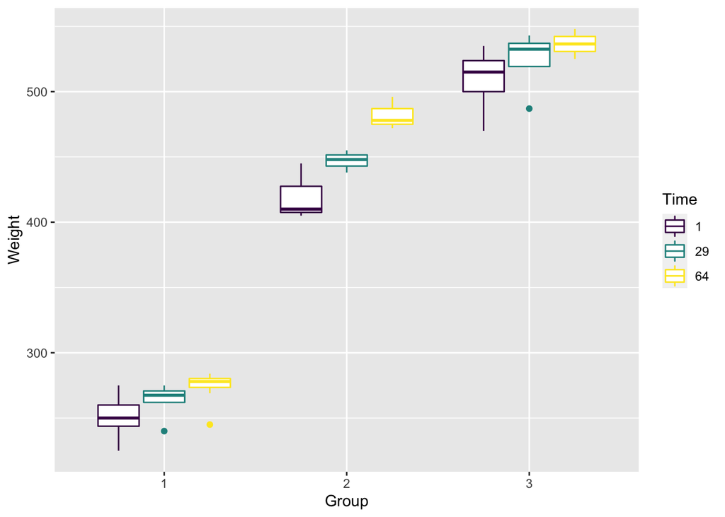

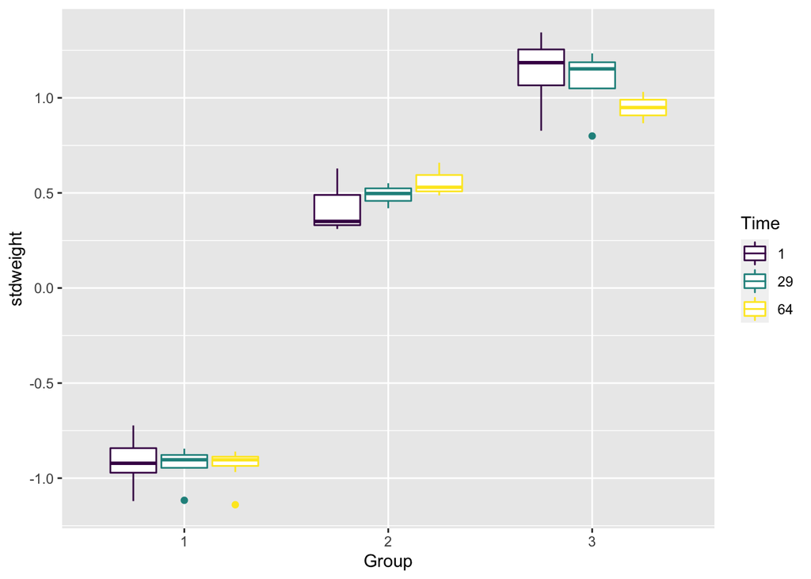

As is clear from these graphs, each group experience growth, but as the second graph shows, only the 2nd groups experiences above-average growth, with Group 1 following the standardized growth and Group 3, in fact, falling behind. This could - theoretically - be due to the diets. To get more formal statistical proof of this relation, we can run the data through a t-test.

```
##    stdweight          Weight           Time      Group
##  Min.   :0.3105   Min.   :405.0   Min.   : 1.0   1:0
##  1st Qu.:0.3844   1st Qu.:418.8   1st Qu.: 1.0   2:6
##  Median :0.5083   Median :458.5   Median :32.5   3:0
##  Mean   :0.4941   Mean   :451.0   Mean   :32.5
##  3rd Qu.:0.6038   3rd Qu.:476.5   3rd Qu.:64.0
##  Max.   :0.6587   Max.   :496.0   Max.   :64.0
```

```
##
##  Two Sample t-test
##
## data:  Weight by Time
## t = -3.3271, df = 14, p-value = 0.004986
## alternative hypothesis: true difference in means is not equal to 0
## 95 percent confidence interval:
##  -38.032466  -8.217534
## sample estimates:
##  mean in group 1 mean in group 64
##          250.625          273.750
```

```
##
##  Two Sample t-test
##
## data:  Weight by Time
## t = -4.275, df = 4, p-value = 0.0129
## alternative hypothesis: true difference in means is not equal to 0
## 95 percent confidence interval:
##  -102.26643  -21.73357
## sample estimates:
##  mean in group 1 mean in group 64
##              420              482
```

```
##
##  Two Sample t-test
##
## data:  Weight by Time
## t = -2.4693, df = 6, p-value = 0.0485
## alternative hypothesis: true difference in means is not equal to 0
## 95 percent confidence interval:
##  -82.6240161  -0.3759839
## sample estimates:
##  mean in group 1 mean in group 64
##           508.75           550.25
```

The T-test analysis indicates rather clearly, that all differences in mean outcome are statistically significant. The clearly higher statistical significance of group 1 results is explained by the higher number of observations, resulting in more reliable observation of true differences

The incorporation of baseline measures is not done in this analysis, as the focus is on the *change* in weight - as opposed to the actual weights. The former is not affected by the higher starting weights. Furthermore, as there are no missing values, the tricks used in MABS Chapter 8 are not necessary here.

## The MABS Chapter 9 Analysis with the BPRS data.

### Introduction

The BPRS dataset covers 40 male subjects who were randomly assigned to one of two treatment groups for psychiatric issues. Each subject was rated with the BPRS-measure, or the “brief psychiatric rating scale (BPRS),” which is used to evaluate patients suspected of having schizophrenia. The BPRS assesses the level of 18 psychiatric issues (inter alia: hostility, suspiciousness, hallucinations and grandiosity), each of these is rated from one (not present) to seven (extremely severe). These BPRS-measures were taken before treatment began (week 0) and then weekly for eight weeks. Below we begin with tables of the BPRS dataset in wide and long form:

```
##     X treatment subject week0 week1 week2 week3 week4 week5 week6 week7 week8
## 1   1         1       1    42    36    36    43    41    40    38    47    51
## 2   2         1       2    58    68    61    55    43    34    28    28    28
## 3   3         1       3    54    55    41    38    43    28    29    25    24
## 4   4         1       4    55    77    49    54    56    50    47    42    46
## 5   5         1       5    72    75    72    65    50    39    32    38    32
## 6   6         1       6    48    43    41    38    36    29    33    27    25
## 7   7         1       7    71    61    47    30    27    40    30    31    31
## 8   8         1       8    30    36    38    38    31    26    26    25    24
## 9   9         1       9    41    43    39    35    28    22    20    23    21
## 10 10         1      10    57    51    51    55    53    43    43    39    32
## 11 11         1      11    30    34    34    41    36    36    38    36    36
## 12 12         1      12    55    52    49    54    48    43    37    36    31
## 13 13         1      13    36    32    36    31    25    25    21    19    22
## 14 14         1      14    38    35    36    34    25    27    25    26    26
```

[output cut: 26 more lines]

```
##     X treatment subject weeks bprs week
## 1   1         1       1 week0   42    0
## 2   2         1       2 week0   58    0
## 3   3         1       3 week0   54    0
## 4   4         1       4 week0   55    0
## 5   5         1       5 week0   72    0
## 6   6         1       6 week0   48    0
## 7   7         1       7 week0   71    0
## 8   8         1       8 week0   30    0
## 9   9         1       9 week0   41    0
## 10 10         1      10 week0   57    0
## 11 11         1      11 week0   30    0
## 12 12         1      12 week0   55    0
## 13 13         1      13 week0   36    0
## 14 14         1      14 week0   38    0
```

[output cut: 16 more lines]

### The Analysis

When possible, model-fitting provides a more rigorous tool for analysing data compared to the above discussed usmmary methods. Nevertheless, with longitudinal data, the key assumption of basic linear models - that observations be independent of other observations - often does not hold. We will begin by showcasing this graphically. Instead of examining the data through a plot that is similar to the “Plot of weight against time for rat data” in chapter 9 of MABS, here the representation of the progression of BPRS scores is done through two linear graphs, each representing one of the treatment groups. I find this much more informative than the slightly confusing numbers-chart referred to above.

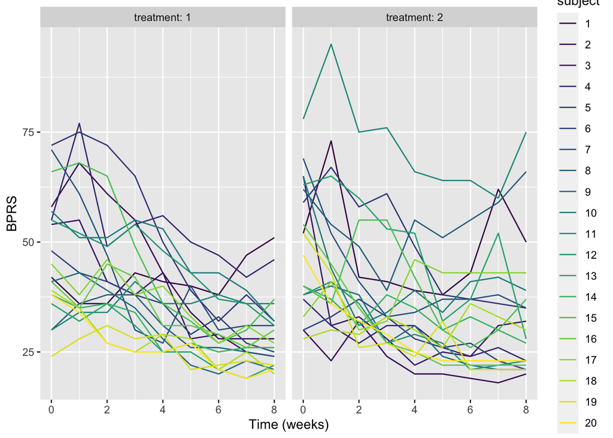

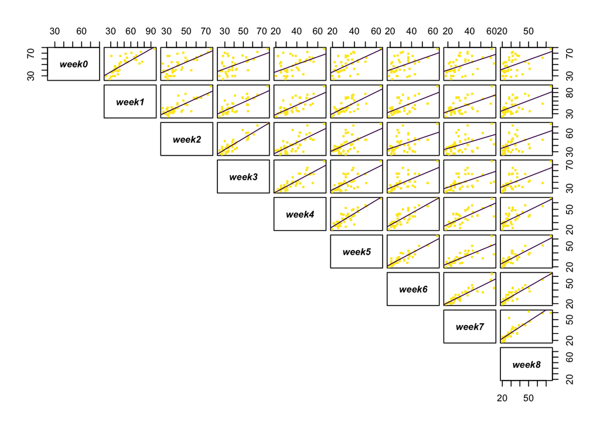

```
##
## Call:
## lm(formula = bprs ~ week + treatment, data = BP_Long)
##
## Residuals:
##     Min      1Q  Median      3Q     Max
## -22.454  -8.965  -3.196   7.002  50.244
##
## Coefficients:
##             Estimate Std. Error t value Pr(>|t|)
## (Intercept)  46.4539     1.3670  33.982   <2e-16 ***
## week         -2.2704     0.2524  -8.995   <2e-16 ***
## treatment2    0.5722     1.3034   0.439    0.661
## ---
## Signif. codes:  0 '***' 0.001 '**' 0.01 '*' 0.05 '.' 0.1 ' ' 1
##
## Residual standard error: 12.37 on 357 degrees of freedom
## Multiple R-squared:  0.1851, Adjusted R-squared:  0.1806
## F-statistic: 40.55 on 2 and 357 DF,  p-value: < 2.2e-16
```

The above graphical representation would seem to provide evidence of the dependent nature of the observations on the previous scores of the subject. They are not completely random, but to an extent paint a trend. This is especially clear in the graphset, which showcases how the results of each week are correlated with the results of the previous weeks.

Additionally, both the graphical representation and the basic linear model seem to indicate that treatment 1 has better results for the bprs scores of the participants. Nevertheless, the graphs are not completely clear due to the large number of subjects, and the basic linear model applied above ignores the repeated-measures structure of the data. As such, it ignores the linkage of observations through by single subjects. More nuanced models can be applied. Below, one can find a gradual progression towards a more complex and fitting linear model.

The first summary data come from the Random Intercept Model, which allows us to abandon the independence assumption between all observations and link observations belonging to one subject. As such, it permits the linear regression fit for each subject to differ in intercept from other subjects.

The next summary data is from the Random Intercept and Random Slope Model, which not only allows each subject to have their own intercept, but also their own slope. This in turn makes it possible incorporate the different progressions of each subject *and* the effect of time.

Finally, the third summary data is from the Random Intercept and Random Slope Model with a focus on week by treatment interaction.

```
## Linear mixed model fit by maximum likelihood  ['lmerMod']
## Formula: bprs ~ week + treatment + (1 | subject)
##    Data: BP_Long
##
##      AIC      BIC   logLik deviance df.resid
##   2748.7   2768.1  -1369.4   2738.7      355
##
## Scaled residuals:
##     Min      1Q  Median      3Q     Max
## -3.0481 -0.6749 -0.1361  0.4813  3.4855
##
## Random effects:
##  Groups   Name        Variance Std.Dev.
##  subject  (Intercept)  47.41    6.885
##  Residual             104.21   10.208
## Number of obs: 360, groups:  subject, 20
##
## Fixed effects:
##             Estimate Std. Error t value
## (Intercept)  46.4539     1.9090  24.334
## week         -2.2704     0.2084 -10.896
## treatment2    0.5722     1.0761   0.532
##
## Correlation of Fixed Effects:
##            (Intr) week
## week       -0.437
## treatment2 -0.282  0.000
```

```
## Linear mixed model fit by maximum likelihood  ['lmerMod']
## Formula: bprs ~ week + treatment + (week | subject)
##    Data: BP_Long
##
##      AIC      BIC   logLik deviance df.resid
##   2745.4   2772.6  -1365.7   2731.4      353
##
## Scaled residuals:
##     Min      1Q  Median      3Q     Max
## -2.8919 -0.6194 -0.0691  0.5531  3.7976
##
## Random effects:
##  Groups   Name        Variance Std.Dev. Corr
##  subject  (Intercept) 64.8222  8.0512
##           week         0.9609  0.9802   -0.51
##  Residual             97.4305  9.8707
## Number of obs: 360, groups:  subject, 20
##
## Fixed effects:
##             Estimate Std. Error t value
## (Intercept)  46.4539     2.1052  22.066
## week         -2.2704     0.2977  -7.626
## treatment2    0.5722     1.0405   0.550
##
## Correlation of Fixed Effects:
##            (Intr) week
## week       -0.582
## treatment2 -0.247  0.000
```

```
## Linear mixed model fit by maximum likelihood  ['lmerMod']
## Formula: bprs ~ week * treatment + (week | subject)
##    Data: BP_Long
##
##      AIC      BIC   logLik deviance df.resid
##   2744.3   2775.4  -1364.1   2728.3      352
##
## Scaled residuals:
##     Min      1Q  Median      3Q     Max
## -3.0512 -0.6271 -0.0768  0.5288  3.9260
##
## Random effects:
##  Groups   Name        Variance Std.Dev. Corr
##  subject  (Intercept) 64.9964  8.0620
##           week         0.9687  0.9842   -0.51
##  Residual             96.4707  9.8220
## Number of obs: 360, groups:  subject, 20
##
## Fixed effects:
##                 Estimate Std. Error t value
## (Intercept)      47.8856     2.2521  21.262
## week             -2.6283     0.3589  -7.323
## treatment2       -2.2911     1.9090  -1.200
## week:treatment2   0.7158     0.4010   1.785
##
## Correlation of Fixed Effects:
##             (Intr) week   trtmn2
## week        -0.650
## treatment2  -0.424  0.469
## wek:trtmnt2  0.356 -0.559 -0.840
```

As we are interested in the model that provides the best representation of the data, we will use the ANOVA-method and examine the resulting p-values of the chi-squared test. The smaller the value, the better the model is compared to the contrasted model. The results of the ANOVAs can be found below:

```
## Data: BP_Long
## Models:
## BP_ri: bprs ~ week + treatment + (1 | subject)
## BP_rirs: bprs ~ week + treatment + (week | subject)
##         npar    AIC    BIC  logLik deviance  Chisq Df Pr(>Chisq)
## BP_ri      5 2748.7 2768.1 -1369.4   2738.7
## BP_rirs    7 2745.4 2772.6 -1365.7   2731.4 7.2721  2    0.02636 *
## ---
## Signif. codes:  0 '***' 0.001 '**' 0.01 '*' 0.05 '.' 0.1 ' ' 1
```

```
## Data: BP_Long
## Models:
## BP_rirs: bprs ~ week + treatment + (week | subject)
## BP_rirsX: bprs ~ week * treatment + (week | subject)
##          npar    AIC    BIC  logLik deviance  Chisq Df Pr(>Chisq)
## BP_rirs     7 2745.4 2772.6 -1365.7   2731.4
## BP_rirsX    8 2744.3 2775.4 -1364.1   2728.3 3.1712  1    0.07495 .
## ---
## Signif. codes:  0 '***' 0.001 '**' 0.01 '*' 0.05 '.' 0.1 ' ' 1
```

```
## Data: BP_Long
## Models:
## BP_ri: bprs ~ week + treatment + (1 | subject)
## BP_rirsX: bprs ~ week * treatment + (week | subject)
##          npar    AIC    BIC  logLik deviance  Chisq Df Pr(>Chisq)
## BP_ri       5 2748.7 2768.1 -1369.4   2738.7
## BP_rirsX    8 2744.3 2775.4 -1364.1   2728.3 10.443  3    0.01515 *
## ---
## Signif. codes:  0 '***' 0.001 '**' 0.01 '*' 0.05 '.' 0.1 ' ' 1
```

The smallest p-value is between the basic random intercept model and the Random Intercept and Random Slope Model which allows from week by treatment interaction. In fact, each move towards a more complicated model produces an improvement in fit. This improvement is not statistically significant between the Random Intercept and Random Slope Model which allows from week by treatment interaction, and the general Random Intercept and Random Slope Model, but the latter is still the preferred one, as it provides the best fit overall, with the highest chi-squared score and lower p-value. As such, going forward, we will apply this model in our analysis.

In the below grahical representation we can see the applicability of our fitted model to the observed bprs scores. the colors indicate the subject within the treatment group.

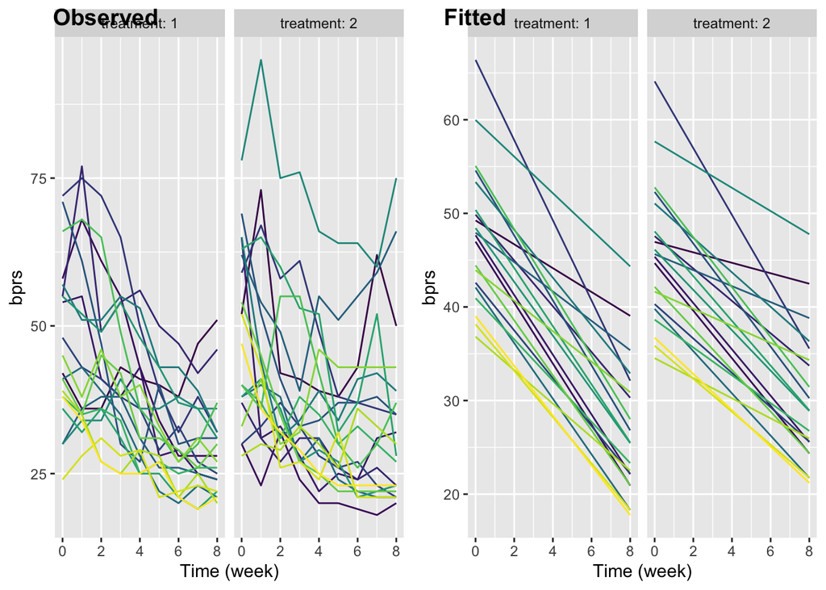

```
## Linear mixed model fit by maximum likelihood  ['lmerMod']
## Formula: bprs ~ week * treatment + (week | subject)
##    Data: BP_Long
##
##      AIC      BIC   logLik deviance df.resid
##   2744.3   2775.4  -1364.1   2728.3      352
##
## Scaled residuals:
##     Min      1Q  Median      3Q     Max
## -3.0512 -0.6271 -0.0768  0.5288  3.9260
##
## Random effects:
##  Groups   Name        Variance Std.Dev. Corr
##  subject  (Intercept) 64.9964  8.0620
##           week         0.9687  0.9842   -0.51
##  Residual             96.4707  9.8220
## Number of obs: 360, groups:  subject, 20
##
## Fixed effects:
##                 Estimate Std. Error t value
## (Intercept)      47.8856     2.2521  21.262
## week             -2.6283     0.3589  -7.323
## treatment2       -2.2911     1.9090  -1.200
## week:treatment2   0.7158     0.4010   1.785
##
## Correlation of Fixed Effects:
##             (Intr) week   trtmn2
## week        -0.650
## treatment2  -0.424  0.469
## wek:trtmnt2  0.356 -0.559 -0.840
```

As can be seen from the above graphical representation, the fitted model provides a decent fit, but not a perfect one. What becomes clear from it though, is the fact that both treatments seem to produce an effect on the bprs-scores. The general trend is a downward one, with Treatment 1 producing slightly lower scores. As the above repretition of the summary shows us, the t-value for the effect of time on the intercept is high enough to indicate statistical significance. The correlation of the fixed effects indicates a medium strong negative correlation.

In case of the treatment type, the correlation of fixed effects gives us a intermediate negative correlation moving from treatment 1 to treatment 2. Nevertheless, the t value for this does not provide sufficient evidence of statistical significance. As such here the null hypothesis - that treatment type has no effect - is not disproved.